title: “Analysis of Riipen’s New Feature” author: “Shannon Simo Komguem, Kai Wang Pong, Eng Sung and JiaQi Zhao” subtitle: STA130 TUT0112-Group 112-1 output: beamer_presentation: default ioslides_presentation: default widescreen: yes

# About the data

Riipen is an education technology company. On November 21, 2018, Riipen launched a “request expiry” feature which requires users to respond to requests within 14 days, or they will expire.

# The Data

```
## Observations: 2,526
## Variables: 8
## $ Id                  <dbl> 2, 3, 4, 5, 6, 7, 8…
## $ `Recipient Id`      <dbl> 1142, 910, 1108, 11…
## $ `Actor Id`          <dbl> 18026, 17140, 11839…
## $ `Requestable Model` <chr> "project", "project…
## $ `Day of Created At` <chr> "12 April, 2018", "…
## $ `Day of Updated At` <chr> "24 April, 2018", "…
## $ `Day of Expired At` <chr> NA, NA, NA, NA, NA,…
## $ State               <chr> "accepted", "accept…
```

# Objectives

How did the November 21 launch of request expiry change user behaviour?

# Data Cleaning

We excluded August 30th, 2018 due to data migration problems.

# Statistical assessments

- Volume of Request
- Response Time
- Regression Model: Response Time and Acceptance Rate

# Volume of Request

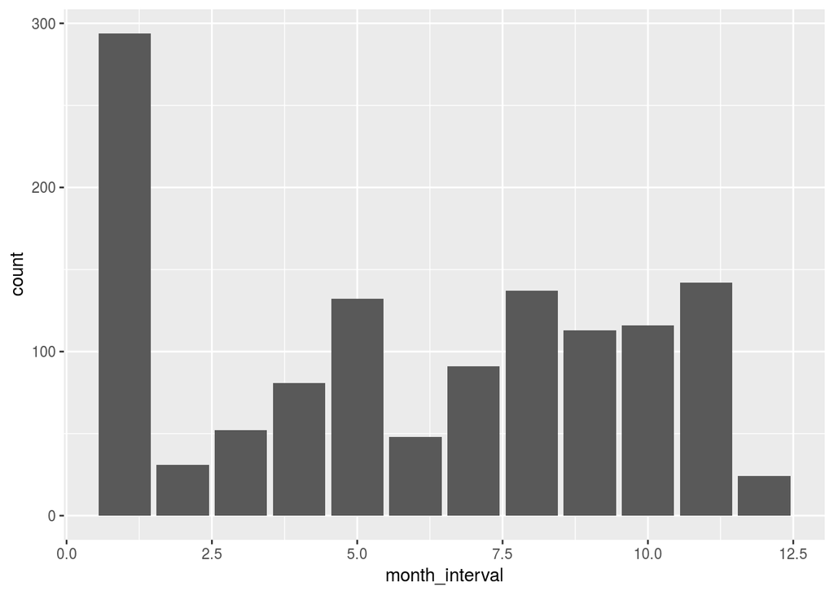

# Volume of Request By User Type

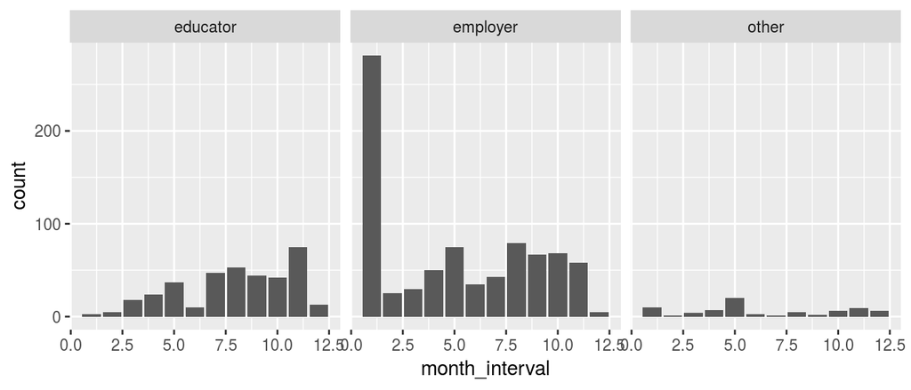

# Respone Time - Data cleaning

- Aug 30
- Pending cases
- Cancelled cases
- Expired cases
- Response Time (in days) = difference of “day of updated” and “day of created”

# Respone Time

```
## # A tibble: 789 x 19
##       id recipient_id actor_id requestable
##    <dbl>        <dbl>    <dbl> <chr>
##  1     2         1142    18026 project
##  2     3          910    17140 project
##  3     6          910    11947 project
##  4     7         1052    17730 project
##  5     9         1161    18096 project
##  6    13         1052    17750 project
##  7    16         1052    17612 project
##  8    18         1156    15377 project
##  9    21         1142    17798 project
## 10    23         1052    15271 project
## # … with 779 more rows, and 15 more variables:
## #   day_created <chr>, day_uploaded <chr>,
## #   day_expired <chr>, state <chr>,
## #   day_created2 <date>, month_created <dbl>,
## #   month_year <chr>, month_interval <dbl>,
## #   sender_type <chr>, recipient_type <chr>,
## #   day_created3 <date>, day_updated <date>,
## #   response_time <time>,
## #   created_before_Nov21 <lgl>,
## #   before_or_after <chr>
```

# Comparison Mean Response Time Before And After Nov21

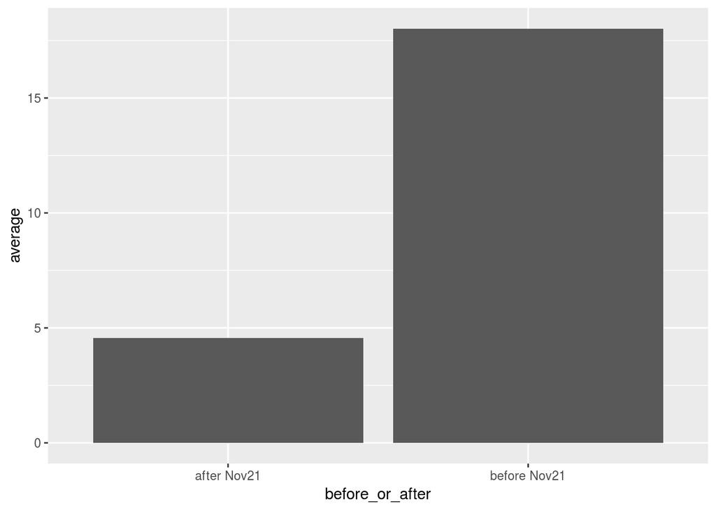